# PHOT 110: Introduction to programming

PHOT 110: Introduction to programming

LECTURE 08: Arrays, vectors & linear algebra (Ch. 5)

Michaël Barbier

Version: April 19, 2026

# More on Arrays

## Array definition

- Arrays have a fixed length
- Array elements have the same type
- We will use arrays from the Numpy library
- Optimized for numerical calculations

```python
# Load the Numpy library
import numpy as np

a = np.array([1, 2, 4, 6, 5, 9])
print(a)
```

```
[1 2 4 6 5 9]
```

## Are arrays faster than lists?

- Accessing array elements is easy & fast:
- Example: array “a” of N integers of size 64-bit
  - i$^{th}$ element is at memory-address: (address of a[0]) + $i \times 64$ bits
  - Copy/change M integers: memory chunk of $M \times 64$ bits

For a list:

- Size can **grow/shrink** & element **types vary** - Elements’ address is in a look-up-table
- i$^{th}$ element is at memory-address at i$^{th}$ table row
- Reading in memory/data chunks is difficult

## Arrays are faster !

**If you do not grow them !**

$$[a_1, .. , a_N] \rightarrow [a_1, .. , a_N, a_{N+1}]$$

- Extending an array of $N$ elements with an extra element:
  - Creates a new array of $N+1$ elements
  - Copies the old array into the new
  - Puts the extra element value in the last position

## Array initialization by casting

```python
import numpy as np

a = np.array([1, 2, 4, 6, 5, 9])
print(a)
```

```
[1 2 4 6 5 9]
```

```python
a = np.array([[6, 0], [7, 4], [2, 9]])
print(a)
```

```
[[6 0]
 [7 4]
 [2 9]]
```

## Array properties

- Shape of the array
- Array dimensions
- Type of the elements
  - Default: 64-bit floats
  - Other options: “uint32”: unsigned 32-bit integers
- Remember: all elements are of same type !

## Get array properties

```python
print(a)
```

```
[[6 0]
 [7 4]
 [2 9]]
```

Shape of an array $\rightarrow$ (rows, columns):

```python
print(a.shape)
```

```
(3, 2)
```

Type of the elements:

```python
print(a.dtype)
```

```
int64
```

## Adapt array properties: element type

```python
print(a)
print(f"Type of the elements is: {a.dtype}")
```

```
[[6 0]
 [7 4]
 [2 9]]
Type of the elements is: int64
```

Change the type to complex 128-bit:

```python
b = a.astype(np.complex128)
print(b)
print(f"Type of the elements is: {b.dtype}")
```

```
[[6.+0.j 0.+0.j]
 [7.+0.j 4.+0.j]
 [2.+0.j 9.+0.j]]
Type of the elements is: complex128
```

## Array initialization

```python
a = np.zeros((4, 3))       # 2D array with zeros
print(a)
```

```
[[0. 0. 0.]
 [0. 0. 0.]
 [0. 0. 0.]
 [0. 0. 0.]]
```

```python
a = np.ones(4)             # 1D array with ones
print(a)
```

```
[1. 1. 1. 1.]
```

## Array initialization

```python
a = np.full((5, 3), 1.2)   # 2D array filled with a value
print(a)
```

```
[[1.2 1.2 1.2]
 [1.2 1.2 1.2]
 [1.2 1.2 1.2]
 [1.2 1.2 1.2]
 [1.2 1.2 1.2]]
```

```python
a = np.full((3, 3), [0.2, 0.3, 1.7])   # 2D array with values
print(a)
```

```
[[0.2 0.3 1.7]
 [0.2 0.3 1.7]
 [0.2 0.3 1.7]]
```

## Array initialization: similar shape

```python
a = np.ones((2, 4))       # 2D array with zeros
print(a)
```

```
[[1. 1. 1. 1.]
 [1. 1. 1. 1.]]
```

```python
a = np.zeros_like(a)       # 2D array with zeros
print(a)
```

```
[[0. 0. 0. 0.]
 [0. 0. 0. 0.]]
```

## Array initialization: similar shape

```python
b = np.full_like(a, 4.5)       # 2D array with zeros
print()
print(f"a = {a}")
print()
print(f"b = {b}")
```

```
a = [[0. 0. 0. 0.]
 [0. 0. 0. 0.]]

b = [[4.5 4.5 4.5 4.5]
 [4.5 4.5 4.5 4.5]]
```

## Empty array initialization

```python
a = np.empty((3, 2))      # empty is not empty !
print(a)
```

```
[[ 3.      0.34  ]
 [ 0.546  34.9   ]
 [ 5.3462  9.    ]]
```

**Fill it** before using !

```python
nx, ny = a.shape
for i in range(nx):
  for j in range(ny):
    a[i, j] = i + 2*j
print(a)
```

```
[[0. 2.]
 [1. 3.]
 [2. 4.]]
```

## Array initialization: intervals

```python
a = np.arange(15)          # similar to range()
print(a)
```

```
[ 0  1  2  3  4  5  6  7  8  9 10 11 12 13 14]
```

```python
a = np.arange(5, 7, 0.3)  # decimal float step
print(a)
```

```
[5.  5.3 5.6 5.9 6.2 6.5 6.8]
```

```python
a = np.linspace(0, 5, 11)  # linearly spaced interval
print(a)
```

```
[0.  0.5 1.  1.5 2.  2.5 3.  3.5 4.  4.5 5. ]
```

## 2D domains/intervals: meshgrid

```python
x = np.linspace(0, 5, 6)
y = 2 ** np.linspace(0, 3, 4)
xx, yy = np.meshgrid(x, y)
```

```python
print(xx)
```

```
[[0. 1. 2. 3. 4. 5.]
 [0. 1. 2. 3. 4. 5.]
 [0. 1. 2. 3. 4. 5.]
 [0. 1. 2. 3. 4. 5.]]
```

```python
print(yy)
```

```
[[1. 1. 1. 1. 1. 1.]
 [2. 2. 2. 2. 2. 2.]
 [4. 4. 4. 4. 4. 4.]
 [8. 8. 8. 8. 8. 8.]]
```

For more on domains see the [Numpy meshgrid howto](https://numpy.org/doc/stable/user/how-to-partition.html#meshgrid).

## Higher dimensional arrays

- Multi-dimensional N-D arrays have N axes

```python
tmp = np.array([[ 1,  2,  3],[ 4,  5,  6],[ 7,  8,  9]])
a = np.array([tmp, 2*tmp, 3*tmp])
print(a)
```

```
[[[ 1  2  3]
  [ 4  5  6]
  [ 7  8  9]]

 [[ 2  4  6]
  [ 8 10 12]
  [14 16 18]]

 [[ 3  6  9]
  [12 15 18]
  [21 24 27]]]
```

## Element selection & Array slicing

- list element selection with `[i]`
- list slicing operator: `[start:end+1:step]`

```python
a = np.array([[ 1,  2,  3],[ 4,  5,  6],[ 7,  8,  9]])
print(f"a[2, 0] = {a[2, 0]}")
print(f"a[0:2:2, :] = {a[0:2:2, :]}")
```

```
a[2, 0] = 7
a[0:2:2, :] = [[1 2 3]]
```

Reduce single dimensions:

```python
print(f"Squeezed a[0:2:2, :] = {np.squeeze(a[0:2:2, :])}")
```

```
Squeezed a[0:2:2, :] = [1 2 3]
```

## Adapting the array shape

```python
a = np.array([[1,5,6,2],[5,3,8,9],[1,1,1,0]])
print(a)
```

```
[[1 5 6 2]
 [5 3 8 9]
 [1 1 1 0]]
```

Flattening the array ND $\rightarrow$ 1D

```python
print(a.flatten())
```

```
[1 5 6 2 5 3 8 9 1 1 1 0]
```

Reshaping array

```python
print(a.reshape((2,6)))
```

```
[[1 5 6 2 5 3]
 [8 9 1 1 1 0]]
```

## Array arithmetic operations

- similar to **arithmetic** operations on numbers
- element-wise
- shapes need to be compatible

```python
a = np.array([2.5, 3, 4])
b = np.array([1, 0.1, 10])
print(f"{a} + {b} = {a + b}")
print(f"{a} * {b} = {a * b}")
print(f"{a} / {b} = {a / b}")
```

```
[2.5 3.  4. ] + [ 1.   0.1 10. ] = [ 3.5  3.1 14. ]
[2.5 3.  4. ] * [ 1.   0.1 10. ] = [ 2.5  0.3 40. ]
[2.5 3.  4. ] / [ 1.   0.1 10. ] = [ 2.5 30.   0.4]
```

## Array logic operations

- similar to **logic** operations on (boolean) numbers
- element-wise
- shapes need to be compatible

```python
a = np.array([1, 3, 4])
b = np.array([1, 1, 10])
print(f"{a} > {b} = {a > b}")
print(f"{a} == {b} = {a == b}")
```

```
[1 3 4] > [ 1  1 10] = [False  True False]
[1 3 4] == [ 1  1 10] = [ True False False]
```

## Array mathematical functions

- Apply mathematical functions similar to math library
- Numpy functions, for example: `math.sin()` $\rightarrow$ `np.sin()`

```python
print(f"sin({a}) = {np.sin(a)}")
```

```
sin([1 3 4]) = [ 0.84147098  0.14112001 -0.7568025 ]
```

```python
print(f"sqrt({a}) = {np.sqrt(a)}")
```

```
sqrt([1 3 4]) = [1.         1.73205081 2.        ]
```

```python
print(f"exp({a}) = {np.exp(a)}")
```

```
exp([1 3 4]) = [ 2.71828183 20.08553692 54.59815003]
```

# Linear algebra: Vectors

## Vectors

A vector is a 1D array, e.g. a column or a row vector:
$$\vec{a} = \pmatrix{a_1\\a_2\\ \vdots \\ a_M} \qquad \vec{b} = \pmatrix{b_1 & b_2 & \dots & b_N}$$

A column vector:

```python
a = np.array([[1],[3],[5]])
print(a)
```

```
[[1]
 [3]
 [5]]
```

## Vectors

A vector is a 1D array, e.g. a column or a row vector:
$$\vec{a} = \pmatrix{a_1\\a_2\\ \vdots \\ a_M} \qquad \vec{b} = \pmatrix{b_1 & b_2 & \dots & b_N}$$

A row vector:

```python
b = np.array([2, 4, 6, 8])
print(b)
```

```
[2 4 6 8]
```

## The scalar product (dot-product)

The scalar product $\vec{a} \cdot \vec{b}$ is defined as **scalar** value

$$\vec{a} \cdot \vec{b} = |a| |b| \cos(\theta)$$

with $\theta$ the angle between $a$ and $b$

**Alternative definition** of the scalar product $\vec{a} \cdot \vec{b}$:

$$\vec{a} \cdot \vec{b} = \sum_{i=1}^d a_i \, b_i$$
where $d$ is the dimension: 2D, 3D, …, ND

## The scalar product (dot-product)

Scalar product $\vec{a} \cdot \vec{b}$ can be computed in Numpy using `np.dot`:

```python
a = np.array([1, -1])
b = np.array([1.5, 2.5])
s = np.dot(a, b)
print(f"{a} . {b} = {s}")
```

```
[ 1 -1] . [1.5 2.5] = -1.0
```

Use `np.vdot` for complex-valued vectors, calculates $\vec{a}^* \cdot \vec{b}$:

```python
a = np.array([-1 + 1j, 1 - 1j])
b = np.array([0, 2j])
print(f"{np.conj(a)} . {b} = {np.vdot(a, b)}")
```

```
[-1.-1.j  1.+1.j] . [0.+0.j 0.+2.j] = (-2+2j)
```

## The scalar product (dot-product)

Scalar product $\vec{a} \cdot \vec{b}$ can be computed in Numpy using `np.dot`:

```python
a = np.array([1, -1])
b = np.array([1.5, 2.5])
s = np.dot(a, b)
print(f"{a} . {b} = {s}")
```

```
[ 1 -1] . [1.5 2.5] = -1.0
```

Higher dimensions than 3 possible:

```python
a = np.array([-1, 2, 2, 2, 1])
b = np.array([0, 0, -3, 3, 2])
print(f"{a} . {b} = {np.dot(a, b)}")
```

```
[-1  2  2  2  1] . [ 0  0 -3  3  2] = 2
```

## Norm of a vector

- Norm of a vector is the length of a vector
- Defined as square root of scalar product:

$$|\vec{a}| = \sqrt{\vec{a}\cdot\vec{a}} = | \pmatrix{a_1 & a_1 & \dots & a_d} | = \sqrt{(\sum_{i=1}^d a_i^2)}$$

```python
import numpy.linalg as la
a = np.array([1, 3, 0, 5])
print(f"The norm of {a} = {la.norm(a)}")
```

```
The norm of [1 3 0 5] = 5.916079783099616
```

## Vector products (cross-product)

The vector product $\vec{a} \times \vec{b}$ is defined as vector $\vec{c}$ with

- Norm $|\vec{a} \times \vec{b}| = |a| |b| \sin(\theta)$
- Perpendicular to surface spanned by $\vec{a}$ and $\vec{b}$

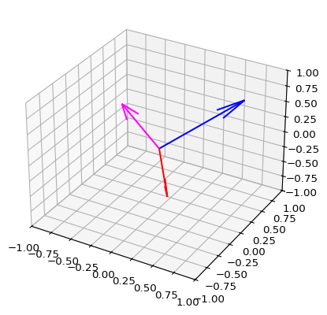

## Vector products

Alternative definition (suitable for computers):

$$\begin{aligned}
\vec{a} \times \vec{b} & = \det\pmatrix{
\vec{e_1} & \vec{e_2} & \vec{e_3}\\
a_1 & a_2 & a_3 \\
b_1 & b_2 & b_3 \\} \\
& \\
& = \begin{vmatrix}
a_2 & a_3\\
b_2 & b_3\\
\end{vmatrix}\vec{e_1} -
\begin{vmatrix}
a_1 & a_3\\
b_1 & b_3\\
\end{vmatrix} \vec{e_2} +
\begin{vmatrix}
a_2 & a_3\\
b_2 & b_3\\
\end{vmatrix}
\vec{e_3} \\
& \\
& = (a_2 b_3 - a_3 b_2) \vec{e_1} - (a_1 b_3 - a_3 b_1) \vec{e_2} + (a_1 b_2 - a_2 b_1) \vec{e_2} \\
\end{aligned}$$

## Vector products

Calculate $\vec{a} \times \vec{b}$ using the Numpy function `np.cross(a, b)`:

```python
a = np.array([1, -1/2, 1])
b = np.array([1/2, 1, 1/2])
c = np.cross(a, b)
print(f"{a} x {b} = {c}")
```

```
[ 1.  -0.5  1. ] x [0.5 1.  0.5] = [-1.25  0.    1.25]
```

# Linear algebra: Matrices

## Array initialization: matrices

```python
a = np.eye(3)             # 2D unity matrix
print(a)
```

```
[[1. 0. 0.]
 [0. 1. 0.]
 [0. 0. 1.]]
```

```python
# Constructing a matrix with "diagonals"
a = np.diagflat([6, 5, 4], 1) + np.diagflat([1, 2, 3], -1)
print(a)
```

```
[[0 6 0 0]
 [1 0 5 0]
 [0 2 0 4]
 [0 0 3 0]]
```

## Matrix products

The matrix product between matrices $A$ and $B$ is defined as

$$\begin{aligned}
A \cdot B & = \pmatrix{
a_{11} & a_{12} & a_{13}\\
a_{21} & a_{22} & a_{23}\\
}
\pmatrix{
b_{11} & b_{12} & b_{13}\\
b_{21} & b_{22} & b_{23}\\
b_{31} & b_{32} & b_{33}\\
}\\
&\\
& = \sum_{j} a_{ij} b_{jk}\\
\end{aligned}$$

- Rows of $A$ are multiplied by columns of $B$.
- $A_{MN} \cdot B_{NK} \leftarrow$ No. columns of $A$ must equal No. rows of $B$

## Matrix products

The matrix product $A \cdot B$ using Numpy `np.matmul()`:

```python
A = np.array([[1,-2,3],[0,2,4]])
B = np.array([[1,-2,3],[0,2,4],[-1,1,0]])
print(A)
```

```
[[ 1 -2  3]
 [ 0  2  4]]
```

```python
print(B)
```

```
[[ 1 -2  3]
 [ 0  2  4]
 [-1  1  0]]
```

```python
print(np.matmul(A, B))
```

```
[[-2 -3 -5]
 [-4  8  8]]
```

## Matrix products

Alternatives to `np.matmul(A, B)` for $A \cdot B$ using Numpy:

- `@` operator: `A @ B`, and
- `np.dot(A, B)`

```python
print(np.matmul(A, B))
```

```
[[-2 -3 -5]
 [-4  8  8]]
```

```python
print(A @ B)
```

```
[[-2 -3 -5]
 [-4  8  8]]
```

```python
print(np.dot(A, B))
```

```
[[-2 -3 -5]
 [-4  8  8]]
```

## Determinant of a matrix

The determinant of a matrix $A$:
$$\begin{aligned}
\det(A) & = \det\pmatrix{
a_{11} & a_{12} & a_{13}\\
a_{21} & a_{22} & a_{23} \\
a_{31} & a_{32} & a_{33} \\} \\
& \\
& = \begin{vmatrix}
a_{22} & a_{23}\\
a_{32} & a_{33}\\
\end{vmatrix} a_{11} -
\begin{vmatrix}
a_{21} & a_{23}\\
a_{31} & a_{33}\\
\end{vmatrix} a_{12} +
\begin{vmatrix}
a_{21} & a_{22}\\
a_{31} & a_{32}\\
\end{vmatrix} a_{13} \\
&\\
& = (a_{22} a_{33} - a_{23} a_{32}) a_{11} - \dots
\\
\end{aligned}$$

## Determinant of a matrix

Use Numpy `numpy.linalg.det()` function

```python
import numpy.linalg as la
A = np.array([[1,-2,3],[0,2,4],[-1,1,0]])
print(A)
```

```
[[ 1 -2  3]
 [ 0  2  4]
 [-1  1  0]]
```

Determinant is given by

```python
print(f"Det(A) = {la.det(A)}")
```

```
Det(A) = 9.999999999999998
```

## Inverse of a matrix

The inverse $A^{-1}$ of a matrix $A$ is defined as:

$$A^{-1} A = A^{-1} A = \mathbb{1}$$

```python
import numpy.linalg as la
A = np.array([[1,-2,3],[0,2,4],[-1,1,0]])
print(A)
print(f"Det(A) = {la.det(A)}")
```

```
[[ 1 -2  3]
 [ 0  2  4]
 [-1  1  0]]
Det(A) = 9.999999999999998
```

## Inverse of a matrix

The inverse $A^{-1}$ of a matrix $A$ is defined as:

$$A^{-1} A = A^{-1} A = \mathbb{1}$$
Since $\det(A) \neq 0 \rightarrow A^{-1}$ exists

```python
Ainv = la.inv(A)
print(Ainv)
```

```
[[-0.4  0.3 -1.4]
 [-0.4  0.3 -0.4]
 [ 0.2  0.1  0.2]]
```

## Inverse of a matrix

The inverse $A^{-1}$ of a matrix $A$ is defined as:

$$A^{-1} A = A^{-1} A = \mathbb{1}$$

Verify $A^{-1} A = \mathbb{1}$:

```python
np.dot(A, Ainv)
```

```
array([[ 1.00000000e+00, -2.77555756e-17, -5.55111512e-17],
       [ 0.00000000e+00,  1.00000000e+00,  0.00000000e+00],
       [ 1.11022302e-16,  5.55111512e-17,  1.00000000e+00]])
```

```python
np.round(np.dot(A, Ainv), 5) # Round numerical errors
```

```
array([[ 1., -0., -0.],
       [ 0.,  1.,  0.],
       [ 0.,  0.,  1.]])
```